# Tutorial of layer visualization

This notebook is provided to show the way to see the built model from autoBioSeqpy. A part of the functions in this notebook is provided in the script "tool/layerPlot.py" as well.

NOTE: The script used 3rd module [UMAP](https://github.com/lmcinnes/umap) for layer plotting.

## 1. Preparation

In this notebook, few packages are necessary.

Assuming that we are in **'root-of-autoBioSeqpy/notebook'**, then we need to add the search path and import the modules.

Please install **UMAP, matplotlib, tensorFlow and keras** before using this notebook.

```python
import os, sys
sys.path.append('../tool/libs')
sys.path.append('../')
oriPath = os.path.curdir
import paraParser
import moduleRead
import dataProcess
#import analysisPlot
import numpy as np
#from sklearn.metrics import accuracy_score,f1_score,roc_auc_score,recall_score,precision_score,confusion_matrix,matthews_corrcoef
import tensorflow as tf
from utils import TextDecorate, evalStrList
from keras.models import Model
from keras.models import Sequential

import umap
import umap.plot
import matplotlib.pyplot as plt
from matplotlib.backends.backend_pdf import PdfPages
```

Using [UMAP](https://github.com/lmcinnes/umap) is a simple way for model visualization, but still we need the model as well as the data for generating the predicted data for plotting. Thus, here we need few steps to get a built model and the related data.

### 1.1 Model building

As the first step, we need a model from running.py, users could build a model by using the command line below in the root of autoBioSeqpy:

**python running.py --dataType dna --dataEncodingType onehot --dataTrainFilePaths examples/CRISPRCas9guideefficiency/data/Doench_high_activity_sgRNA.txt examples/CRISPRCas9guideefficiency/data/Doench_low_activity_sgRNA.txt --dataTrainLabel 1 0 --dataSplitScale 0.8 --modelLoadFile examples/CRISPRCas9guideefficiency/model/DNA_CNN2D_model.py --verbose 1 --outSaveFolderPath tmpOut --savePrediction 1 --saveFig 1 --batch_size 25 --epochs 40 --shuffleDataTrain 1 --spcLen 30 --firstKernelSize 4 5 --modelSaveName tmpMod.json --weightSaveName tmpWeight.bin --noGPU 0 --paraSaveName parameters.txt**

The outputs will be saved at **../tmpOut**, including the parameters, the path of the data and constructure of the model.

Alternativly, ususally a built model is already provided in **../tmpOut**, thus users could skip this step by using the provided one.

If users would like to use their own model, please don't forget to save the model and the weight by using parameters "--modelSaveName" and "--weightSaveName".

### 1.2 Parameter pasering and data loading

The parameters are saved in **../tmoOut/parameters.txt**, we can get the information easily by using the **paraParser** module.

```python
paraFile = '../tmpOut/parameters.txt'
paraDict = paraParser.parseParametersFromFile(paraFile)
#print
for k in paraDict:
    print('%r: %r' %(k,paraDict[k]))
```

```
'dataType': ['dna']
'dataEncodingType': ['onehot']
'spcLen': [30]
'firstKernelSize': ['4', '5']
'dataTrainFilePaths': ['examples/CRISPRCas9guideefficiency/data/Doench_high_activity_sgRNA.txt', 'examples/CRISPRCas9guideefficiency/data/Doench_low_activity_sgRNA.txt']
'dataTrainLabel': [1, 0]
'dataTestFilePaths': []
'dataTestLabel': []
'dataTrainModelInd': []
'dataTestModelInd': []
'outSaveFolderPath': 'tmpOut'
'showFig': True
'saveFig': True
'figDPI': 300
'savePrediction': True
'dataSplitScale': 0.8
'modelLoadFile': ['examples/CRISPRCas9guideefficiency/model/DNA_CNN2D_model.py']
'weightLoadFile': []
'shuffleDataTrain': True
'shuffleDataTest': False
'batch_size': 25
'epochs': 40
'useKMer': []
'KMerNum': []
'inputLength': []
'loss': 'binary_crossentropy'
'optimizer': 'optimizers.Adam()'
'metrics': ['acc', 'acc']
'modelSaveName': 'tmpMod.json'
'weightSaveName': 'tmpWeight.bin'
'noGPU': False
'paraFile': None
'paraSaveName': 'parameters.txt'
'seed': 1
'labelToMat': False
'colorText': 'Auto'
'verbose': True
'reshapeSize': []
```

Few preparing...

```python
paraDict['dataTestFilePaths'] = paraDict['dataTrainFilePaths']
paraDict['dataTestModelInd'] = paraDict['dataTrainModelInd']
paraDict['dataTestLabel'] = paraDict['dataTrainLabel']
os.chdir('../')#to the root path of autoBioSeqpy


#parameters
dataTypeList = paraDict['dataType']
dataEncodingType = paraDict['dataEncodingType']
spcLen = paraDict['spcLen']
firstKernelSize = paraDict['firstKernelSize']

dataTestFilePaths = paraDict['dataTestFilePaths']
dataTestLabel = paraDict['dataTestLabel']

dataSplitScale = paraDict['dataSplitScale']
outSaveFolderPath = paraDict['outSaveFolderPath']
showFig = paraDict['showFig']
saveFig = paraDict['saveFig']
savePrediction = paraDict['savePrediction']

loss = paraDict['loss']
optimizer = paraDict['optimizer']
if not optimizer.startswith('optimizers.'):
    optimizer = 'optimizers.' + optimizer
if not optimizer.endswith('()'):
    optimizer = optimizer + '()'
metrics = paraDict['metrics']

shuffleDataTrain = paraDict['shuffleDataTrain']
shuffleDataTest = paraDict['shuffleDataTest']
batch_size = paraDict['batch_size']
epochs = paraDict['epochs']

inputLength = paraDict['inputLength']
modelSaveName = paraDict['modelSaveName']
weightSaveName = paraDict['weightSaveName']
noGPU = paraDict['noGPU']
labelToMat = paraDict['labelToMat']


modelLoadFile = paraDict['modelLoadFile']
useKMerList = paraDict['useKMer']
if len(useKMerList ) == 0:
    useKMerList = [False] * len(modelLoadFile)
KMerNumList = paraDict['KMerNum']
if len(KMerNumList ) == 0:
    KMerNumList = [3] * len(modelLoadFile)

dataTestModelInd = paraDict['dataTestModelInd']
if len(modelLoadFile) == 1:
    dataTestModelInd = [0] * len(dataTestFilePaths)

modelPredictFile = outSaveFolderPath + os.path.sep + modelSaveName
weightLoadFile = outSaveFolderPath + os.path.sep + weightSaveName


model = moduleRead.readModelFromJsonFileDirectly(modelPredictFile,weightLoadFile)
```

Then we begin to generate the dataset by encoding the sequences.

The code below is from predicting.py, to see how the code works, please see the other notebook '**tutorial in jupyter notebook.ipynb**' instead.

```python
td = TextDecorate()

verbose = paraDict['verbose']

predictionSavePath = None
for i,k in enumerate(sys.argv):
    if k == '--predictionSavePath':
        predictionSavePath = sys.argv[i+1]
    elif k == '--verbose':
        verbose = sys.argv[i+1]

colorText = paraDict['colorText']
if colorText.lower() == 'auto':
    import platform
    if 'win' in platform.system().lower():
        td.disable()
elif not bool(eval(colorText)):
    td.disable()

if noGPU:
    if verbose:
        td.printC('As set by user, gpu will be disabled.','g')
    os.environ["CUDA_VISIBLE_DEVICES"] = '-1'
else:
    #check the version of tensorflow before configuration
    tfVersion = tf.__version__
    if int(tfVersion.split('.')[0]) >= 2:
        config = tf.compat.v1.ConfigProto()
        config.gpu_options.allow_growth = True

        sess =tf.compat.v1.Session(config=config)
    else:
        config = tf.ConfigProto(gpu_options=tf.GPUOptions(allow_growth=True))
        sess = tf.Session(config=config)


if not len(dataTypeList) == len(modelLoadFile):
    if verbose:
        td.printC('Please provide enough data type(s) as the number of --modelLoadFile','r')
assert len(dataTypeList) == len(modelLoadFile)

featureGenerators = []
for i,subDataType in enumerate(dataTypeList):
    if subDataType.lower() == 'protein':
        if verbose:
            td.printC('Enconding protein data for model %d ...' %i,'b')
        featureGenerator = dataProcess.ProteinFeatureGenerator(dataEncodingType[i], useKMer=useKMerList[i], KMerNum=KMerNumList[i])
    elif subDataType.lower() == 'dna':
        if verbose:
            td.printC('Enconding DNA data for model %d ...' %i,'b')
        featureGenerator = dataProcess.DNAFeatureGenerator(dataEncodingType[i], useKMer=useKMerList[i], KMerNum=KMerNumList[i])
    elif subDataType.lower() == 'rna':
        if verbose:
            td.printC('Enconding RNA data for model %d ...' %i,'b')
        featureGenerator = dataProcess.RNAFeatureGenerator(dataEncodingType[i], useKMer=useKMerList[i], KMerNum=KMerNumList[i])
    elif subDataType.lower() == 'other':
        if verbose:
            td.printC('Reading CSV-like data for model %d ...' %i,'b')
        featureGenerator = dataProcess.OtherFeatureGenerator()
    else:
        td.printC('Unknow dataType %r, please use \'protein\', \'dna\' ,\'rna\' or \'other\'' %subDataType, 'r')
    featureGenerators.append(featureGenerator)
    assert subDataType.lower() in ['protein','dna','rna','other']

if verbose:
    td.printC('Checking the number of test files, which should be larger than 1 (e.g. at least two labels)...','b')
assert len(dataTestFilePaths) > 0

if verbose:
    td.printC('Begin to generate test dataset...','b')

testDataLoadDict = {}
for modelIndex in range(len(modelLoadFile)):
    testDataLoadDict[modelIndex] = []
#    testDataLoaders = []
for i,dataPath in enumerate(dataTestFilePaths):
    modelIndex = dataTestModelInd[i]
    featureGenerator = featureGenerators[modelIndex]
    dataLoader = dataProcess.DataLoader(label = dataTestLabel[i], featureGenerator=featureGenerator)
    dataLoader.readFile(dataPath, spcLen = spcLen[modelIndex])
    testDataLoadDict[modelIndex].append(dataLoader)

testDataMats = []
testLabelArrs = []
testNameLists = []
for modelIndex in range(len(modelLoadFile)):
    testDataLoaders = testDataLoadDict[modelIndex]
    testDataSetCreator = dataProcess.DataSetCreator(testDataLoaders)
    testDataMat, testLabelArr, nameList = testDataSetCreator.getDataSet(toShuffle=False, withNameList=True)
    testDataMats.append(testDataMat)
    testLabelArrs.append(testLabelArr)
    testNameLists.append(nameList)
if verbose:
    td.printC('Test datasets generated.','g')
nameTemp = testNameLists[0]
testDataMats, testLabelArrs, sortedIndexes = dataProcess.matAlignByName(testDataMats,nameTemp,testLabelArrs,testNameLists)
testNameLists = [nameTemp] * len(testNameLists)

tmpTempLabel = testLabelArrs[0]
for tmpLabel in testLabelArrs:
    assert np.sum(np.array(tmpTempLabel) - np.array(tmpLabel)) == 0

if labelToMat:
    if verbose:
        td.printC('Since labelToMat is set, the labels would be changed to onehot-like matrix','g')
    testLabelArr,testLabelArrDict,testArrLabelDict = dataProcess.labelToMat(testLabelArrs[0])
#    print(testLabelArr)
else:
    testLabelArr = testLabelArrs[0]
```

```
Enconding DNA data for model 0 ...
Checking the number of test files, which should be larger than 1 (e.g. at least two labels)...
Begin to generate test dataset...
Test datasets generated.
```

```python
print('%d matrix generated:\n' %(len(testDataMats)))
for i in range(len(testDataMats)):
    print('Matrix and label %d:' %i)
    print(testDataMats[i])
    print(testLabelArrs[i])
    print('\n')
```

```
1 matrix generated:

Matrix and label 0:
[[0 0 0 ... 0 0 1]
 [1 0 0 ... 1 0 0]
 [0 1 0 ... 0 0 0]
 ...
 [0 0 1 ... 0 0 0]
 [0 0 1 ... 0 0 0]
 [1 0 0 ... 0 0 1]]
[1 1 1 1 1 1 1 1 1 1 1 1 1 1 1 1 1 1 1 1 1 1 1 1 1 1 1 1 1 1 1 1 1 1 1 1 1
 1 1 1 1 1 1 1 1 1 1 1 1 1 1 1 1 1 1 1 1 1 1 1 1 1 1 1 1 1 1 1 1 1 1 1 1 1
 1 1 1 1 1 1 1 1 1 1 1 1 1 1 1 1 1 1 1 1 1 1 1 1 1 1 1 1 1 1 1 1 1 1 1 1 1
 1 1 1 1 1 1 1 1 1 1 1 1 1 1 1 1 1 1 1 1 1 1 1 1 1 1 1 1 1 1 1 1 1 1 1 1 1
 1 1 1 1 1 1 1 1 1 1 1 1 1 1 1 1 1 1 1 1 1 1 1 1 1 1 1 1 1 1 1 1 1 1 1 1 1
 1 1 1 1 1 1 1 1 1 1 1 1 1 1 1 1 1 1 1 1 1 1 1 1 1 1 1 1 1 1 1 1 1 1 1 1 1
 1 1 1 1 1 1 1 1 1 1 1 1 1 1 1 1 1 1 1 1 1 1 1 1 1 1 1 1 1 1 1 1 1 1 1 1 1
 1 1 1 1 1 1 1 1 1 1 1 1 1 1 1 1 1 1 1 1 1 1 1 1 1 1 1 1 1 1 1 1 1 1 1 1 1
 1 1 1 1 1 1 1 1 1 1 1 1 1 1 1 1 1 1 1 1 1 1 1 1 1 1 1 1 1 1 1 1 1 1 1 1 1
 1 1 1 1 1 1 1 1 1 1 1 1 1 1 1 1 1 1 1 1 1 1 1 1 1 1 1 1 1 1 1 1 1 1 1 0 0
 0 0 0 0 0 0 0 0 0 0 0 0 0 0 0 0 0 0 0 0 0 0 0 0 0 0 0 0 0 0 0 0 0 0 0 0 0
 0 0 0 0 0 0 0 0 0 0 0 0 0 0 0 0 0 0 0 0 0 0 0 0 0 0 0 0 0 0 0 0 0 0 0 0 0
 0 0 0 0 0 0 0 0 0 0 0 0 0 0 0 0 0 0 0 0 0 0 0 0 0 0 0 0 0 0 0 0 0 0 0 0 0
 0 0 0 0 0 0 0 0 0 0 0 0 0 0 0 0 0 0 0 0 0 0 0 0 0 0 0 0 0 0 0 0 0 0 0 0 0
 0 0 0 0 0 0 0 0 0 0 0 0 0 0 0 0 0 0 0 0 0 0 0 0 0 0 0 0 0 0 0 0 0 0 0 0 0
 0 0 0 0 0 0 0 0 0 0 0 0 0 0 0 0 0 0 0 0 0 0 0 0 0 0 0 0 0 0 0 0 0 0 0 0 0
 0 0 0 0 0 0 0 0 0 0 0 0 0 0 0 0 0 0 0 0 0 0 0 0 0 0 0 0 0 0 0 0 0 0 0 0 0
 0 0 0 0 0 0 0 0 0 0 0 0 0 0 0 0 0 0 0 0 0 0 0 0 0 0 0 0 0 0 0 0 0 0 0 0 0
 0 0 0 0 0 0 0 0 0 0 0 0 0 0 0 0 0 0 0 0 0 0 0 0 0 0 0 0 0 0 0 0 0 0 0 0 0
 0 0 0 0 0 0 0 0 0 0 0 0 0 0 0 0 0 0 0 0 0 0 0 0 0 0 0 0 0 0 0 0 0]
```

### 1.3 model loading

Using the **moduleRead** module could load the model easily, then the components are ready.

```python
if verbose:
    td.printC('Checking module file for modeling','b')
if modelPredictFile is None:
    if verbose:
        td.printC('please provide a model file in a json file.','r')
if weightLoadFile is None:
    if verbose:
        td.printC('the weight file is necessary for predicting, otherwise the model will be with initialized weight','r')
assert not modelPredictFile is None
assert not weightLoadFile is None

if verbose:
    td.printC('Loading module and weight file','b')
model = moduleRead.readModelFromJsonFileDirectly(modelPredictFile,weightLoadFile)
if verbose:
    td.printC('Module loaded, generating the summary of the module','b')
    model.summary()
```

```
Checking module file for modeling
Loading module and weight file
Module loaded, generating the summary of the module
Model: "sequential_2"
_________________________________________________________________
Layer (type)                 Output Shape              Param #
=================================================================
reshape_1 (Reshape)          (None, 20, 6, 1)          0
_________________________________________________________________
sequential_1 (Sequential)    (None, 1)                 115481
=================================================================
Total params: 115,481
Trainable params: 115,481
Non-trainable params: 0
_________________________________________________________________
```

The model will be different as user set. Some times there will be a "sequential" layer, which is a wrapped model, in the summary, this time, we can umpack the "sequential" layer into 'un-wrapped' layers.

We provided few functions in 'layPlot.py', but here we can do it manually.

First of all, let us see what is in the sequential. A function is used to make this process more simple.

```python
def unBoundLayers(modelIn,layers = []):
    for layer in modelIn.layers:
        if not 'sequential' in layer.name.lower():
            layers.append(layer)
        else:
            unBoundLayers(layer,layers)
    return layers
```

```python
layers = unBoundLayers(model)
for i, layer in enumerate(layers):
    print('layer %d: %s' %(i,layer.name))
```

```
layer 0: reshape_1
layer 1: conv2d_1
layer 2: average_pooling2d_1
layer 3: flatten_1
layer 4: dropout_1
layer 5: dense_1
layer 6: dropout_2
layer 7: dense_2
layer 8: dropout_3
layer 9: dense_3
layer 10: dropout_4
layer 11: dense_4
layer 12: activation_1
```

Then, merge them into a sequential model.

Since the data UMAP need is not the finall output from the full connection layer, usually we only need to use few of the layers. For example, if we only use the layers until the 3rd last layers, the code becomes:

```python
newModel = Sequential()
for layer in layers[:-3]:
    newModel.add(layer)
newModel.summary()
```

```
Model: "sequential_1"
_________________________________________________________________
Layer (type)                 Output Shape              Param #
=================================================================
reshape_1 (Reshape)          (None, 20, 6, 1)          0
_________________________________________________________________
conv2d_1 (Conv2D)            (None, 17, 2, 80)         1680
_________________________________________________________________
average_pooling2d_1 (Average (None, 17, 1, 80)         0
_________________________________________________________________
flatten_1 (Flatten)          (None, 1360)              0
_________________________________________________________________
dropout_1 (Dropout)          (None, 1360)              0
_________________________________________________________________
dense_1 (Dense)              (None, 80)                108880
_________________________________________________________________
dropout_2 (Dropout)          (None, 80)                0
_________________________________________________________________
dense_2 (Dense)              (None, 40)                3240
_________________________________________________________________
dropout_3 (Dropout)          (None, 40)                0
_________________________________________________________________
dense_3 (Dense)              (None, 40)                1640
=================================================================
Total params: 115,440
Trainable params: 115,440
Non-trainable params: 0
_________________________________________________________________
```

Now the model above is available for UMAP.

NOTE: Usually we have to spesify the input shape of the input layer, but autoBioSeqpy will check when training, thus here we don't have to do this step.

## 2. Using UMAP for layer visualization

UMAP need the predicted values from the model and the labels from the data, then the figure could be generated.

```python
predicted_Probability = newModel.predict(testDataMats)
```

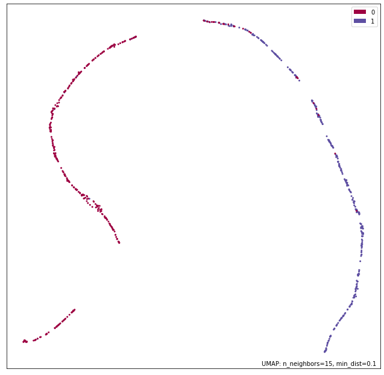

```python
# the featureDict could contain more parameters, use '?umap.UMAP' for more details.
featureDict={
        'n_neighbors' : 15,
        'min_dist' : 0.1,
        }

mapper = umap.UMAP(**featureDict).fit(predicted_Probability)
plotObj = umap.plot.points(mapper, labels=testLabelArr)
plt.show()
```

Sometimes we need more parameters for finding better performance, then the code becoms:

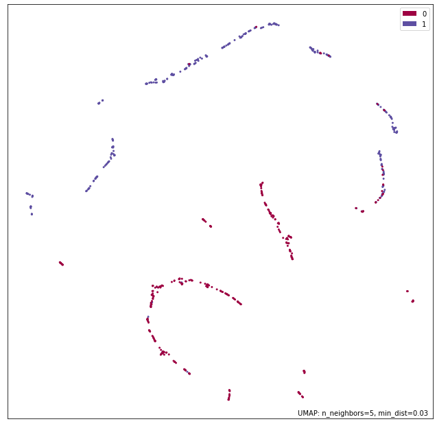

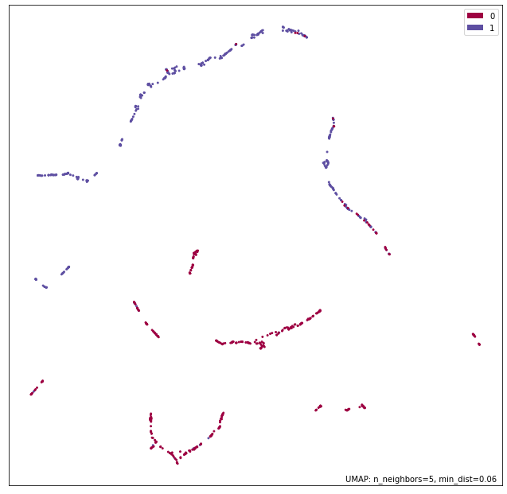

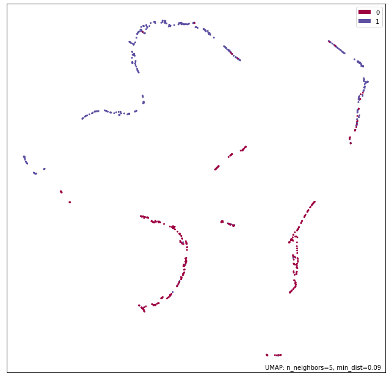

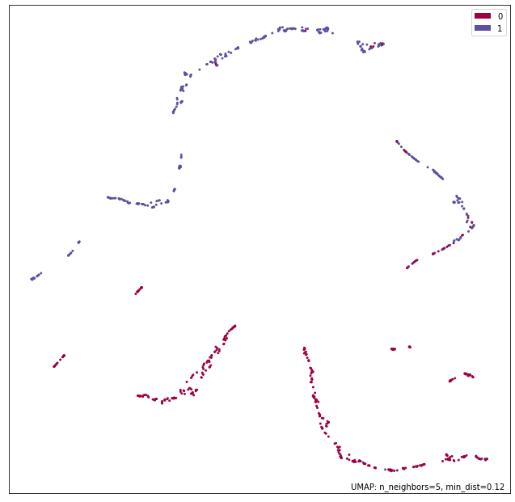

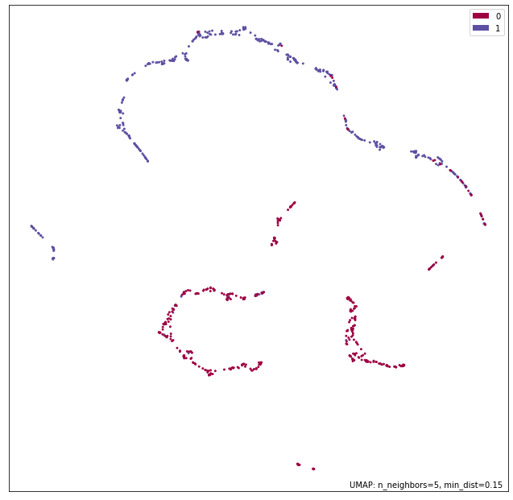

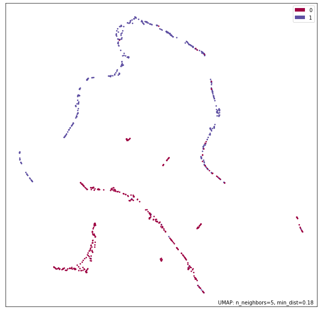

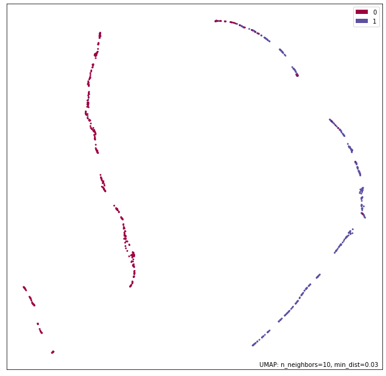

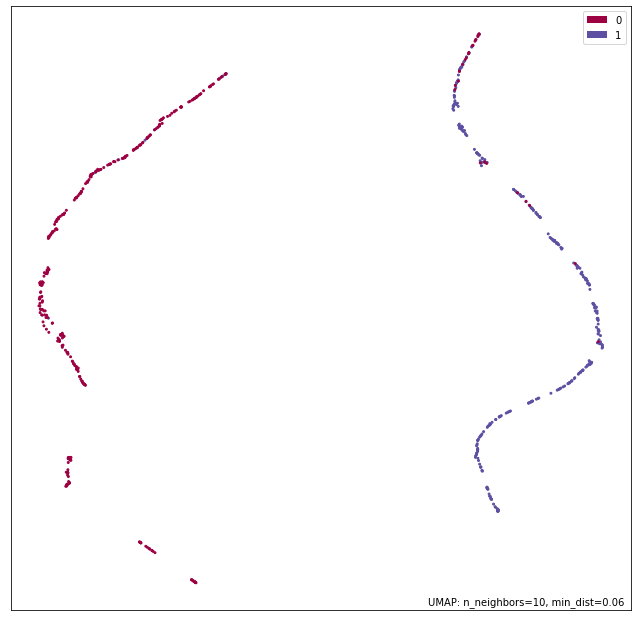

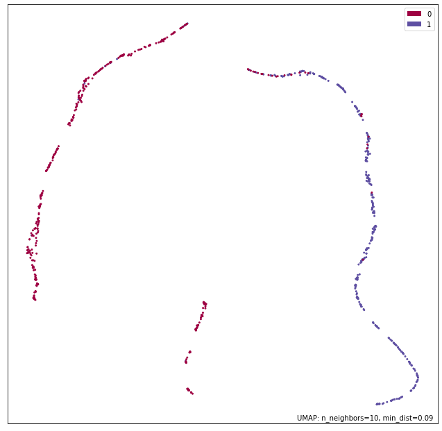

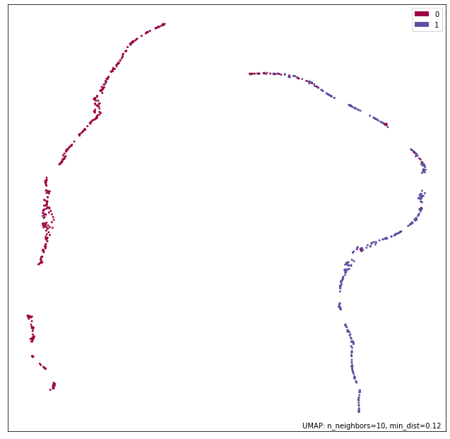

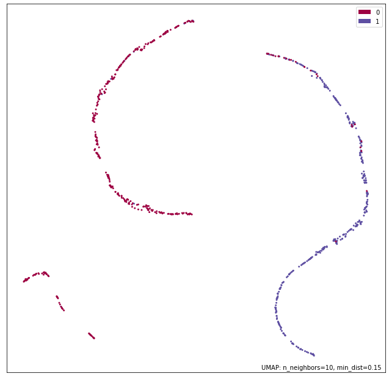

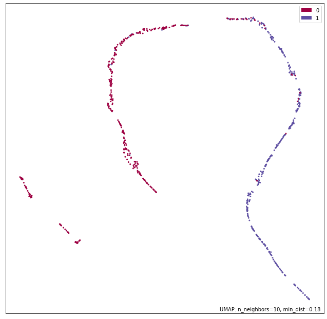

[18 more figures not shown]

```python
featureDict={
        'n_neighbors' : 15,
        'min_dist' : 0.1,
        }
for n_neighbors in np.arange(5,30,5).astype(int):
    featureDict['n_neighbors'] = n_neighbors
    for min_dist in np.arange(0.03,0.2,0.03):
        featureDict['min_dist'] = min_dist
        mapper = umap.UMAP(**featureDict).fit(predicted_Probability)
        plotObj = umap.plot.points(mapper, labels=testLabelArr)
        plt.show()
        plt.close() #close the plotted figure
```

More elements are available in featureDict, users can see details by using '**?umap.UMAP**'or '**help(umap.UMAP)**'

```python
help(umap.UMAP)
```

```
Help on class UMAP in module umap.umap_:

class UMAP(sklearn.base.BaseEstimator)
 |  UMAP(n_neighbors=15, n_components=2, metric='euclidean', metric_kwds=None, output_metric='euclidean', output_metric_kwds=None, n_epochs=None, learning_rate=1.0, init='spectral', min_dist=0.1, spread=1.0, low_memory=False, set_op_mix_ratio=1.0, local_connectivity=1.0, repulsion_strength=1.0, nega…
 |  Uniform Manifold Approximation and Projection
 |  Finds a low dimensional embedding of the data that approximates
 |  an underlying manifold.
 |  Parameters
 |  ----------
 |  n_neighbors: float (optional, default 15)
 |      The size of local neighborhood (in terms of number of neighboring
 |      sample points) used for manifold approximation. Larger values
 |      result in more global views of the manifold, while smaller
 |      values result in more local data being preserved. In general
 |      values should be in the range 2 to 100.
 |  n_components: int (optional, default 2)
 |      The dimension of the space to embed into. This defaults to 2 to
 |      provide easy visualization, but can reasonably be set to any
 |      integer value in the range 2 to 100.
 |  metric: string or function (optional, default 'euclidean')
 |      The metric to use to compute distances in high dimensional space.
 |      If a string is passed it must match a valid predefined metric. If
 |      a general metric is required a function that takes two 1d arrays and
 |      returns a float can be provided. For performance purposes it is
 |      required that this be a numba jit'd function. Valid string metrics
 |      include:
 |          * euclidean
 |          * manhattan
 |          * chebyshev
 |          * minkowski
 |          * canberra
 |          * braycurtis
 |          * mahalanobis
 |          * wminkowski
 |          * seuclidean
 |          * cosine
 |          * correlation
 |          * haversine
 |          * hamming
 |          * jaccard
```

[output cut: 200 more lines]

```
 |      component of a nested object.
 |      Parameters
 |      ----------
 |      **params : dict
 |          Estimator parameters.
 |      Returns
 |      -------
 |      self : object
 |          Estimator instance.
 |  ----------------------------------------------------------------------
 |  Data descriptors inherited from sklearn.base.BaseEstimator:
 |  __dict__
 |      dictionary for instance variables (if defined)
 |  __weakref__
 |      list of weak references to the object (if defined)
```

If we want to use different distance metric, the code becomes to:

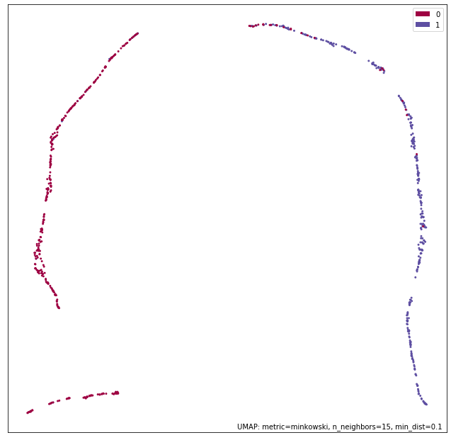

```python
featureDict={
        'n_neighbors' : 15,
        'min_dist' : 0.1,
        'metric' : 'minkowski',
        }

mapper = umap.UMAP(**featureDict).fit(predicted_Probability)
plotObj = umap.plot.points(mapper, labels=testLabelArr)
plt.show()
```

Until now, we can use UMAP for plotting the module from autoBioSeqpy.

## 3. Additional case: for mergered models

Considering that autoBioSeqpy is able to merge multiple neural network by using the 'concatenate' layer, here we simply introduced this condition.

First, we need to generate a mergered model, like:

**python running.py --dataType dna dna --dataEncodingType onehot onehot --dataTrainFilePaths examples/CRISPRCas9guideefficiency/data/Doench_high_activity_sgRNA.txt examples/CRISPRCas9guideefficiency/data/Doench_low_activity_sgRNA.txt examples/CRISPRCas9guideefficiency/data/Doench_high_activity_sgRNA.txt examples/CRISPRCas9guideefficiency/data/Doench_low_activity_sgRNA.txt --dataTrainLabel 1 0 1 0 --dataSplitScale 0.8 --modelLoadFile examples/CRISPRCas9guideefficiency/model/tmp2D.py examples/CRISPRCas9guideefficiency/model/tmp2D2mer.py --verbose 1 --outSaveFolderPath tmpOut --savePrediction 1 --saveFig 1 --batch_size 25 --epochs 40 --shuffleDataTrain 1 --spcLen 30 40 --modelSaveName tmpMod.json --weightSaveName tmpWeight.bin --noGPU 0 --paraSaveName parameters.txt --dataTrainModelInd 0 0 1 1 --useKMer 0 1 --KMerNum 0 2 --showFig 0**

Running it in the root path of autoBioSeqpy, then the output is generated in '../tmpOut'.

Then following the progress above

```python
if os.path.exists('notebook')
    os.chdir('notebook')
paraFile = '../tmpOut/parameters.txt' #please be careful about the path
paraDict = paraParser.parseParametersFromFile(paraFile)
#print
for k in paraDict:
    print('%r: %r' %(k,paraDict[k]))
```

```
'dataType': ['dna', 'dna']
'dataEncodingType': ['onehot', 'onehot']
'spcLen': [30, 40]
'firstKernelSize': []
'dataTrainFilePaths': ['examples/CRISPRCas9guideefficiency/data/Doench_high_activity_sgRNA.txt', 'examples/CRISPRCas9guideefficiency/data/Doench_low_activity_sgRNA.txt', 'examples/CRISPRCas9guideefficiency/data/Doench_high_activity_sgRNA.txt', 'examples/CRISPRCas9guideefficiency/data/Doench_low_acti…
'dataTrainLabel': [1, 0, 1, 0]
'dataTestFilePaths': []
'dataTestLabel': []
'dataTrainModelInd': [0, 0, 1, 1]
'dataTestModelInd': []
'outSaveFolderPath': 'tmpOut'
'showFig': False
'saveFig': True
'figDPI': 300
'savePrediction': True
'dataSplitScale': 0.8
'modelLoadFile': ['examples/CRISPRCas9guideefficiency/model/tmp2D.py', 'examples/CRISPRCas9guideefficiency/model/tmp2D2mer.py']
'weightLoadFile': []
'shuffleDataTrain': True
'shuffleDataTest': False
'batch_size': 25
'epochs': 40
'useKMer': [False, True]
'KMerNum': [0, 2]
'inputLength': []
'loss': 'binary_crossentropy'
'optimizer': 'optimizers.Adam()'
'metrics': ['acc', 'acc']
'modelSaveName': 'tmpMod.json'
'weightSaveName': 'tmpWeight.bin'
'noGPU': False
'paraFile': None
'paraSaveName': 'parameters.txt'
'seed': 1
'labelToMat': False
'colorText': 'Auto'
'verbose': True
'reshapeSize': []
```

```python
paraDict['dataTestFilePaths'] = paraDict['dataTrainFilePaths']
paraDict['dataTestModelInd'] = paraDict['dataTrainModelInd']
paraDict['dataTestLabel'] = paraDict['dataTrainLabel']
os.chdir('../')#to the root path of autoBioSeqpy


#parameters
dataTypeList = paraDict['dataType']
dataEncodingType = paraDict['dataEncodingType']
spcLen = paraDict['spcLen']
firstKernelSize = paraDict['firstKernelSize']

dataTestFilePaths = paraDict['dataTestFilePaths']
dataTestLabel = paraDict['dataTestLabel']

dataSplitScale = paraDict['dataSplitScale']
outSaveFolderPath = paraDict['outSaveFolderPath']
showFig = paraDict['showFig']
saveFig = paraDict['saveFig']
savePrediction = paraDict['savePrediction']

loss = paraDict['loss']
optimizer = paraDict['optimizer']
if not optimizer.startswith('optimizers.'):
    optimizer = 'optimizers.' + optimizer
if not optimizer.endswith('()'):
    optimizer = optimizer + '()'
metrics = paraDict['metrics']

shuffleDataTrain = paraDict['shuffleDataTrain']
shuffleDataTest = paraDict['shuffleDataTest']
batch_size = paraDict['batch_size']
epochs = paraDict['epochs']

inputLength = paraDict['inputLength']
modelSaveName = paraDict['modelSaveName']
weightSaveName = paraDict['weightSaveName']
noGPU = paraDict['noGPU']
labelToMat = paraDict['labelToMat']


modelLoadFile = paraDict['modelLoadFile']
useKMerList = paraDict['useKMer']
if len(useKMerList ) == 0:
    useKMerList = [False] * len(modelLoadFile)
KMerNumList = paraDict['KMerNum']
if len(KMerNumList ) == 0:
    KMerNumList = [3] * len(modelLoadFile)

dataTestModelInd = paraDict['dataTestModelInd']
if len(modelLoadFile) == 1:
    dataTestModelInd = [0] * len(dataTestFilePaths)

modelPredictFile = outSaveFolderPath + os.path.sep + modelSaveName
weightLoadFile = outSaveFolderPath + os.path.sep + weightSaveName


model = moduleRead.readModelFromJsonFileDirectly(modelPredictFile,weightLoadFile)
```

```python
td = TextDecorate()

verbose = paraDict['verbose']

predictionSavePath = None
for i,k in enumerate(sys.argv):
    if k == '--predictionSavePath':
        predictionSavePath = sys.argv[i+1]
    elif k == '--verbose':
        verbose = sys.argv[i+1]

colorText = paraDict['colorText']
if colorText.lower() == 'auto':
    import platform
    if 'win' in platform.system().lower():
        td.disable()
elif not bool(eval(colorText)):
    td.disable()

if noGPU:
    if verbose:
        td.printC('As set by user, gpu will be disabled.','g')
    os.environ["CUDA_VISIBLE_DEVICES"] = '-1'
else:
    #check the version of tensorflow before configuration
    tfVersion = tf.__version__
    if int(tfVersion.split('.')[0]) >= 2:
        config = tf.compat.v1.ConfigProto()
        config.gpu_options.allow_growth = True

        sess =tf.compat.v1.Session(config=config)
    else:
        config = tf.ConfigProto(gpu_options=tf.GPUOptions(allow_growth=True))
        sess = tf.Session(config=config)


if not len(dataTypeList) == len(modelLoadFile):
    if verbose:
        td.printC('Please provide enough data type(s) as the number of --modelLoadFile','r')
assert len(dataTypeList) == len(modelLoadFile)

featureGenerators = []
for i,subDataType in enumerate(dataTypeList):
    if subDataType.lower() == 'protein':
        if verbose:
            td.printC('Enconding protein data for model %d ...' %i,'b')
        featureGenerator = dataProcess.ProteinFeatureGenerator(dataEncodingType[i], useKMer=useKMerList[i], KMerNum=KMerNumList[i])
    elif subDataType.lower() == 'dna':
        if verbose:
            td.printC('Enconding DNA data for model %d ...' %i,'b')
        featureGenerator = dataProcess.DNAFeatureGenerator(dataEncodingType[i], useKMer=useKMerList[i], KMerNum=KMerNumList[i])
    elif subDataType.lower() == 'rna':
        if verbose:
            td.printC('Enconding RNA data for model %d ...' %i,'b')
        featureGenerator = dataProcess.RNAFeatureGenerator(dataEncodingType[i], useKMer=useKMerList[i], KMerNum=KMerNumList[i])
    elif subDataType.lower() == 'other':
        if verbose:
            td.printC('Reading CSV-like data for model %d ...' %i,'b')
        featureGenerator = dataProcess.OtherFeatureGenerator()
    else:
        td.printC('Unknow dataType %r, please use \'protein\', \'dna\' ,\'rna\' or \'other\'' %subDataType, 'r')
    featureGenerators.append(featureGenerator)
    assert subDataType.lower() in ['protein','dna','rna','other']

if verbose:
    td.printC('Checking the number of test files, which should be larger than 1 (e.g. at least two labels)...','b')
assert len(dataTestFilePaths) > 0

if verbose:
    td.printC('Begin to generate test dataset...','b')

testDataLoadDict = {}
for modelIndex in range(len(modelLoadFile)):
    testDataLoadDict[modelIndex] = []
#    testDataLoaders = []
for i,dataPath in enumerate(dataTestFilePaths):
    modelIndex = dataTestModelInd[i]
    featureGenerator = featureGenerators[modelIndex]
    dataLoader = dataProcess.DataLoader(label = dataTestLabel[i], featureGenerator=featureGenerator)
    dataLoader.readFile(dataPath, spcLen = spcLen[modelIndex])
    testDataLoadDict[modelIndex].append(dataLoader)

testDataMats = []
testLabelArrs = []
testNameLists = []
for modelIndex in range(len(modelLoadFile)):
    testDataLoaders = testDataLoadDict[modelIndex]
    testDataSetCreator = dataProcess.DataSetCreator(testDataLoaders)
    testDataMat, testLabelArr, nameList = testDataSetCreator.getDataSet(toShuffle=False, withNameList=True)
    testDataMats.append(testDataMat)
    testLabelArrs.append(testLabelArr)
    testNameLists.append(nameList)
if verbose:
    td.printC('Test datasets generated.','g')
nameTemp = testNameLists[0]
testDataMats, testLabelArrs, sortedIndexes = dataProcess.matAlignByName(testDataMats,nameTemp,testLabelArrs,testNameLists)
testNameLists = [nameTemp] * len(testNameLists)

tmpTempLabel = testLabelArrs[0]
for tmpLabel in testLabelArrs:
    assert np.sum(np.array(tmpTempLabel) - np.array(tmpLabel)) == 0

if labelToMat:
    if verbose:
        td.printC('Since labelToMat is set, the labels would be changed to onehot-like matrix','g')
    testLabelArr,testLabelArrDict,testArrLabelDict = dataProcess.labelToMat(testLabelArrs[0])
#    print(testLabelArr)
else:
    testLabelArr = testLabelArrs[0]
```

```
Enconding DNA data for model 0 ...
Enconding DNA data for model 1 ...
Checking the number of test files, which should be larger than 1 (e.g. at least two labels)...
Begin to generate test dataset...
Test datasets generated.
```

```python
print('%d matrix generated:\n' %(len(testDataMats)))
for i in range(len(testDataMats)):
    print('Matrix and label %d:' %i)
    print(testDataMats[i])
    print(testLabelArrs[i])
    print('\n')
```

```
2 matrix generated:

Matrix and label 0:
[[0 0 0 ... 0 0 1]
 [1 0 0 ... 1 0 0]
 [0 1 0 ... 0 0 0]
 ...
 [0 0 1 ... 0 0 0]
 [0 0 1 ... 0 0 0]
 [1 0 0 ... 0 0 1]]
[1 1 1 1 1 1 1 1 1 1 1 1 1 1 1 1 1 1 1 1 1 1 1 1 1 1 1 1 1 1 1 1 1 1 1 1 1
 1 1 1 1 1 1 1 1 1 1 1 1 1 1 1 1 1 1 1 1 1 1 1 1 1 1 1 1 1 1 1 1 1 1 1 1 1
 1 1 1 1 1 1 1 1 1 1 1 1 1 1 1 1 1 1 1 1 1 1 1 1 1 1 1 1 1 1 1 1 1 1 1 1 1
 1 1 1 1 1 1 1 1 1 1 1 1 1 1 1 1 1 1 1 1 1 1 1 1 1 1 1 1 1 1 1 1 1 1 1 1 1
 1 1 1 1 1 1 1 1 1 1 1 1 1 1 1 1 1 1 1 1 1 1 1 1 1 1 1 1 1 1 1 1 1 1 1 1 1
```

[output cut: 45 more lines]

```python
if verbose:
    td.printC('Checking module file for modeling','b')
if modelPredictFile is None:
    if verbose:
        td.printC('please provide a model file in a json file.','r')
if weightLoadFile is None:
    if verbose:
        td.printC('the weight file is necessary for predicting, otherwise the model will be with initialized weight','r')
assert not modelPredictFile is None
assert not weightLoadFile is None

if verbose:
    td.printC('Loading module and weight file','b')
model = moduleRead.readModelFromJsonFileDirectly(modelPredictFile,weightLoadFile)
if verbose:
    td.printC('Module loaded, generating the summary of the module','b')
    model.summary()
```

```
Checking module file for modeling
Loading module and weight file
Module loaded, generating the summary of the module
Model: "model_1"
__________________________________________________________________________________________________
Layer (type)                    Output Shape         Param #     Connected to
==================================================================================================
reshape_1_input (InputLayer)    (None, 120)          0
__________________________________________________________________________________________________
reshape_2_input (InputLayer)    (None, 624)          0
__________________________________________________________________________________________________
reshape_1 (Reshape)             (None, 20, 6, 1)     0           reshape_1_input[0][0]
__________________________________________________________________________________________________
reshape_2 (Reshape)             (None, 52, 12, 1)    0           reshape_2_input[0][0]
__________________________________________________________________________________________________
sequential_1 (Sequential)       (None, 40)           115440      reshape_1[0][0]
__________________________________________________________________________________________________
sequential_2 (Sequential)       (None, 40)           1261040     reshape_2[0][0]
__________________________________________________________________________________________________
concatenate_1 (Concatenate)     (None, 80)           0           sequential_1[1][0]
                                                                 sequential_2[1][0]
__________________________________________________________________________________________________
dense_7 (Dense)                 (None, 1)            81          concatenate_1[0][0]
==================================================================================================
Total params: 1,376,561
Trainable params: 1,376,561
Non-trainable params: 0
__________________________________________________________________________________________________
```

Now we can see, the 'concatenate' layer is in the model. In this case, we can only use the layers after concatenate layer (including the concatenate layer) as the output layer if we want to keep the inputs.

```python
newModel=Model(inputs=model.input,outputs=model.layers[-2].output) #using the concatenate_1 as the output layer
newModel.summary()
```

```
Model: "model_1"
__________________________________________________________________________________________________
Layer (type)                    Output Shape         Param #     Connected to
==================================================================================================
reshape_1_input (InputLayer)    (None, 120)          0
__________________________________________________________________________________________________
reshape_2_input (InputLayer)    (None, 624)          0
__________________________________________________________________________________________________
reshape_1 (Reshape)             (None, 20, 6, 1)     0           reshape_1_input[0][0]
__________________________________________________________________________________________________
reshape_2 (Reshape)             (None, 52, 12, 1)    0           reshape_2_input[0][0]
__________________________________________________________________________________________________
sequential_1 (Sequential)       (None, 40)           115440      reshape_1[0][0]
__________________________________________________________________________________________________
sequential_2 (Sequential)       (None, 40)           1261040     reshape_2[0][0]
__________________________________________________________________________________________________
concatenate_1 (Concatenate)     (None, 80)           0           sequential_1[1][0]
                                                                 sequential_2[1][0]
==================================================================================================
Total params: 1,376,480
Trainable params: 1,376,480
Non-trainable params: 0
__________________________________________________________________________________________________
```

```python
predicted_Probability = newModel.predict(testDataMats)
```

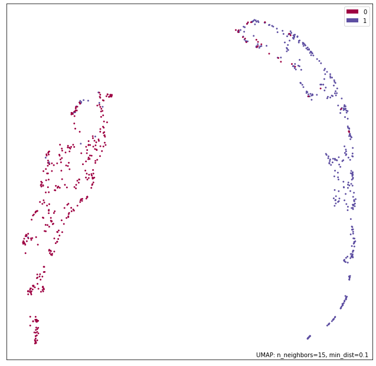

```python
featureDict={
        'n_neighbors' : 15,
        'min_dist' : 0.1,
        }

mapper = umap.UMAP(**featureDict).fit(predicted_Probability)
plotObj = umap.plot.points(mapper, labels=testLabelArr)
plt.show()
```

That's straightforward, but some times we want to see the middle, the things becomes a little complex.

```python
model.summary()#see the summary again
```

```
Model: "model_1"
__________________________________________________________________________________________________
Layer (type)                    Output Shape         Param #     Connected to
==================================================================================================
reshape_1_input (InputLayer)    (None, 120)          0
__________________________________________________________________________________________________
reshape_2_input (InputLayer)    (None, 624)          0
__________________________________________________________________________________________________
reshape_1 (Reshape)             (None, 20, 6, 1)     0           reshape_1_input[0][0]
__________________________________________________________________________________________________
reshape_2 (Reshape)             (None, 52, 12, 1)    0           reshape_2_input[0][0]
__________________________________________________________________________________________________
sequential_1 (Sequential)       (None, 40)           115440      reshape_1[0][0]
__________________________________________________________________________________________________
sequential_2 (Sequential)       (None, 40)           1261040     reshape_2[0][0]
__________________________________________________________________________________________________
concatenate_1 (Concatenate)     (None, 80)           0           sequential_1[1][0]
                                                                 sequential_2[1][0]
__________________________________________________________________________________________________
dense_7 (Dense)                 (None, 1)            81          concatenate_1[0][0]
==================================================================================================
Total params: 1,376,561
Trainable params: 1,376,561
Non-trainable params: 0
__________________________________________________________________________________________________
```

In this example, there are two models which are mergered:

reshape_1_input -- reshape_1 -- sequential_1 -|  
reshape_2_input -- reshape_2 -- sequential_2 -- concatenate_1 -- dense_7

We can choose one to build the sequential:

```python
layers = model.layers
for i, layer in enumerate(layers):
    print('layer %d: %s' %(i,layer.name))
```

```
layer 0: reshape_1_input
layer 1: reshape_2_input
layer 2: reshape_1
layer 3: reshape_2
layer 4: sequential_1
layer 5: sequential_2
layer 6: concatenate_1
layer 7: dense_7
```

If we choose "reshape_2_input -- reshape_2 -- sequential_2", then we can build a sequential only use the specified layers

```python
def unBoundLayers(modelIn,layers = []):
    for layer in modelIn.layers:
        if not 'sequential' in layer.name.lower():
            layers.append(layer)
        else:
            unBoundLayers(layer,layers)
    return layers
```

```python
sublayers = unBoundLayers(model.layers[5],layers = [])
for i, layer in enumerate(sublayers):
    print('layer %d: %s' %(i,layer.name))
```

```
layer 0: conv2d_2
layer 1: average_pooling2d_2
layer 2: flatten_2
layer 3: dropout_5
layer 4: dense_4
layer 5: dropout_6
layer 6: dense_5
layer 7: dropout_7
layer 8: dense_6
layer 9: dropout_8
```

```python
newModel1 = Sequential()
newModel1.add(model.layers[1])
newModel1.add(model.layers[3])
for layer in sublayers[:-3]:
    newModel1.add(layer)
newModel1.summary()
```

```
Model: "sequential_2"
_________________________________________________________________
Layer (type)                 Output Shape              Param #
=================================================================
reshape_2 (Reshape)          (None, 52, 12, 1)         0
_________________________________________________________________
conv2d_2 (Conv2D)            (None, 49, 8, 80)         1680
_________________________________________________________________
average_pooling2d_2 (Average (None, 49, 4, 80)         0
_________________________________________________________________
flatten_2 (Flatten)          (None, 15680)             0
_________________________________________________________________
dropout_5 (Dropout)          (None, 15680)             0
_________________________________________________________________
dense_4 (Dense)              (None, 80)                1254480
_________________________________________________________________
dropout_6 (Dropout)          (None, 80)                0
_________________________________________________________________
dense_5 (Dense)              (None, 40)                3240
=================================================================
Total params: 1,259,400
Trainable params: 1,259,400
Non-trainable params: 0
_________________________________________________________________
```

Then the input should be specified carefully:

```python
predicted_Probability = newModel1.predict(testDataMats[1]) #not testDataMats, it's testDataMats[1]
```

Finally, we got the plots.

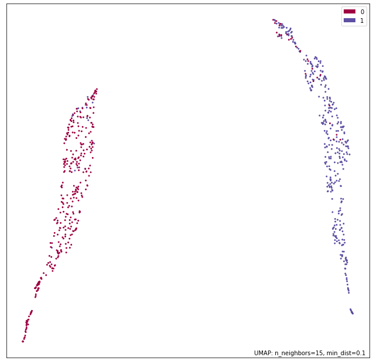

```python
featureDict={
        'n_neighbors' : 15,
        'min_dist' : 0.1,
        }

mapper = umap.UMAP(**featureDict).fit(predicted_Probability)
plotObj = umap.plot.points(mapper, labels=testLabelArr)
plt.show()
```

That's all the informations for plotting the layer by using their outputs and UMAP. If you still have more issues, please fell free to connect us at ljs@swmu.edu.cn, thanks.